# hw2

# Information

**the Github website for this homework is https://github.com/jiayihu-Jeffery/506hw2**

# Problem 1 - Modified Random walk

Consider a 1-dimensional random walk with the following rules:

1. Start at 0.
2. At each step, move +1 or -1 with 50/50 probability.
3. If +1 is chosen, 5% of the time move +10 instead.
4. If -1 is chosen, 20% of the time move -3 instead.
5. Repeat steps 2-4 \(n\) times.

(Note that if the +10 is chosen, it’s not +1 then +10, it is just +10.)

Write a function to determine the end position of this random walk.

The input and output should be:

- Input: The number of steps
- Output: The final position of the walk

  > random_walk(10)

  > [1] 4

  > random_walk(10)

  > [1] -11

We’re going to implement this in different ways and compare them.

## a.

Implement the random walk in these three versions:

- Version 1: using a loop.
- Version 2: using built-in R vectorized functions. (Using no loops.) (Hint: Does the order of steps matter?)
- Version 3: Implement the random walk using one of the “`apply`” functions.

Demonstrate that all versions work by running the following:

```
random_walk1(10)
random_walk2(10)
random_walk3(10)
random_walk1(1000)
random_walk2(1000)
random_walk3(1000)
```

### Version 1: for-loop

We can calculate the overall probability of each of the four possible outcomes:

$$\begin{aligned}
P(+1) &= P(\text{positive direction}) \times P(+1 \mid \text{positive}) = 0.5 \times 0.95 = 0.475 \\
P(+10) &= P(\text{positive direction}) \times P(+10 \mid \text{positive}) = 0.5 \times 0.05 = 0.025 \\
P(-1) &= P(\text{negative direction}) \times P(-1 \mid \text{negative}) = 0.5 \times 0.80 = 0.4 \\
P(-3) &= P(\text{negative direction}) \times P(-3 \mid \text{positive}) = 0.5 \times 0.20 = 0.1
\end{aligned}$$

```r
random_walk1 <- function(n) {
  position <- 0
  for (i in 1:n) {
    step <- sample(c(1, 10, -1, -3), 1, prob = c(0.475, 0.025, 0.4, 0.1))
    position <- position + step
  }
  return(position)
}
```

### Version 2: vectorized functions (no loops)

```r
random_walk2 <- function(n) {
  #compose all_steps as a vector, [1] indicate the first step we move how far.
  all_steps <- sample(c(1, 10, -1, -3),
                      size = n,
                      replace = TRUE,
                      prob = c(0.475, 0.025, 0.4, 0.1))
  return(sum(all_steps))
}
```

### Version 3: vapply (professor said it’s safest apply function)

```r
random_walk3 <- function(n) {
  #parameter 'dummy' is not used, just a placeholder for vapply
  step <- function(dummy) {
    sample(c(1, 10, -1, -3), 1, prob = c(0.475, 0.025, 0.4, 0.1))
  }

  # Use vapply to repeat the step function n times
  all_steps <- vapply(1:n, step, numeric(1))

  sum(all_steps)
}
```

### Demonstration

```r
random_walk1(10)
```

```
[1] -4
```

```r
random_walk2(10)
```

```
[1] -4
```

```r
random_walk3(10)
```

```
[1] 9
```

```r
random_walk1(1000)
```

```
[1] 30
```

```r
random_walk2(1000)
```

```
[1] 54
```

```r
random_walk3(1000)
```

```
[1] 20
```

## b.

Demonstrate that the three versions can give the same result.Show this for both `n=10` and `n=1000`. (You will need to add a way to control the randomization.)

```r
# using setseed to control the randomization
set.seed(1); random_walk1(10)
```

```
[1] -8
```

```r
set.seed(1); random_walk2(10)
```

```
[1] -8
```

```r
set.seed(1); random_walk3(10)
```

```
[1] -8
```

```r
set.seed(1); random_walk1(1000)
```

```
[1] 50
```

```r
set.seed(1); random_walk2(1000)
```

```
[1] 50
```

```r
set.seed(1); random_walk3(1000)
```

```
[1] 50
```

## c.

Use the **microbenchmark** package to clearly demonstrate the speed of the implementations.Compare performance with a low input (1,000) and a large input (100,000). Discuss the results.

```r
library(microbenchmark)
library(ggplot2)

# Compare performance for n = 1,000
mb_small <- microbenchmark(
  loop      = random_walk1(1000),
  vector    = random_walk2(1000),
  vapply_fn = random_walk3(1000),
  times = 100
)

# change 100 times to 20 times for n = 100,000 to reduce computation time
mb_large <- microbenchmark(
  loop      = random_walk1(100000),
  vector    = random_walk2(100000),
  vapply_fn = random_walk3(100000),
  times = 20
)

print(mb_small)
```

```
Unit: microseconds
      expr      min        lq       mean   median       uq      max neval
      loop 2877.700 3017.3515 3466.16512 3311.551 3599.801 5391.301   100
    vector   15.901   18.5515   22.52999   20.801   25.651   45.100   100
 vapply_fn 3324.001 3463.7510 4084.08901 3885.601 4278.401 8296.601   100
```

```r
print(mb_large)
```

```
Unit: milliseconds
      expr        min         lq       mean     median         uq        max
      loop 345.999101 360.754151 379.569576 371.880852 395.885951 431.296101
    vector   1.399901   1.491701   1.606526   1.603001   1.684251   1.964401
 vapply_fn 390.945002 407.126151 419.427866 417.097051 427.672051 459.414101
 neval
    20
    20
    20
```

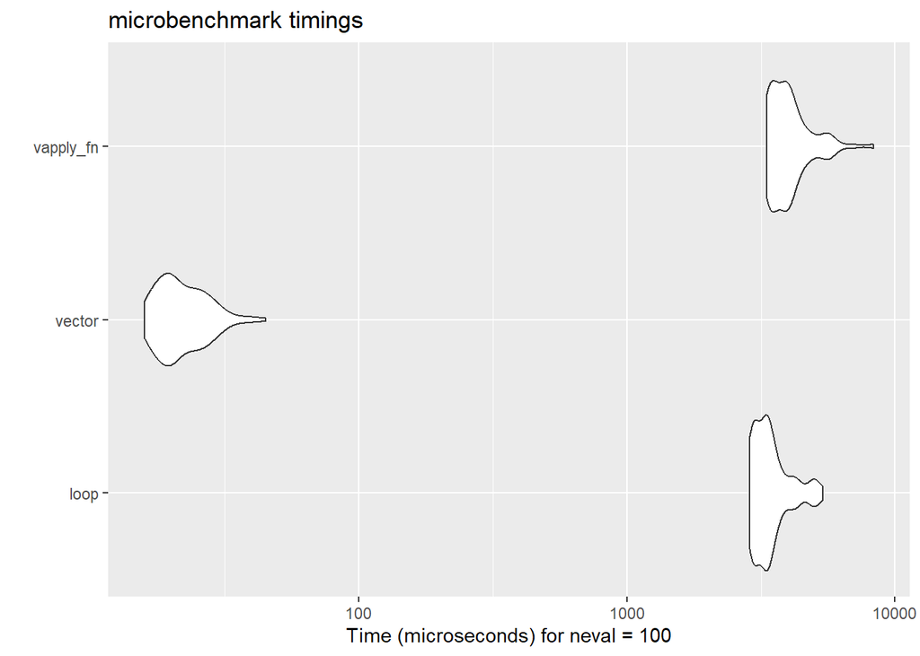

```r
autoplot(mb_small)
```

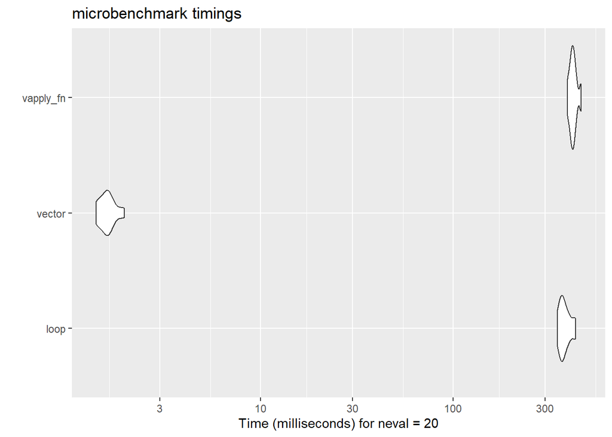

```r
autoplot(mb_large)
```

## d.

What is the probability that the random walk ends at 0 if the number of steps is 10? 100? 1000? Defend your answers with evidence based upon a Monte Carlo simulation.

```r
#set MCMC times
n <- 100000

#use random_walk2 for MCMC simulation
random_walk2_MCMC10 <- replicate(n, random_walk2(10))
random_walk2_MCMC100 <- replicate(n, random_walk2(100))
random_walk2_MCMC1000 <- replicate(n, random_walk2(1000))

#calculate the probability
Prob10 = sum(random_walk2_MCMC10 == 0) /n
Prob100 = sum(random_walk2_MCMC100 == 0) /n
Prob1000 = sum(random_walk2_MCMC1000 == 0) /n

print(Prob10)
```

```
[1] 0.13035
```

```r
print(Prob100)
```

```
[1] 0.01939
```

```r
print(Prob1000)
```

```
[1] 0.00573
```

# Problem 2 - Mean of Mixture of Distributions

The number of cars passing an intersection is a classic example of a Poisson distribution. At a particular intersection, Poisson is an appropriate distribution most of the time, but during rush hours (hours of 8am and 5pm) the distribution is really normally distributed with a much higher mean.

Using a Monte Carlo simulation, estimate the average number of cars that pass an intersection under the following assumptions:

- From midnight until 7 AM, the distribution of cars per hour is Poisson with mean 1.
- From 9am to 4pm, the distribution of cars per hour is Poisson with mean 8.
- From 6pm to 11pm, the distribution of cars per hour is Poisson with mean 12.
- During rush hours (8am and 5pm), the distribution of cars per hour is Normal with mean 60 and variance 12

Accomplish this **without using any loops**.

(Hint: This can be done with extremely minimal code.)

```r
M <- 1000000
sigma_rush <- sqrt(12)

# Create a matrix where each row is a day and each column is an hour
X <- cbind(
  matrix(rpois(M * 8, 1),  M, 8),# 0–7h, first creat a vectir of 8M elements, then convert it to a M*8 matrix
  round(pmax(0, rnorm(M, 60, sigma_rush))),  # 8h, round and pmax to ensure non-negative integers
  matrix(rpois(M * 8, 8),  M, 8),# 9–16h
  round(pmax(0, rnorm(M, 60, sigma_rush))), # 17h
  matrix(rpois(M * 6, 12), M, 6) # 18–23h
)

head(X)
```

```
     [,1] [,2] [,3] [,4] [,5] [,6] [,7] [,8] [,9] [,10] [,11] [,12] [,13] [,14]
[1,]    0    1    2    2    1    0    2    2   59     5     6    19     5     7
[2,]    1    1    1    0    1    0    1    3   59     9    10     6     6     7
[3,]    0    2    2    0    0    1    0    1   63     7     3     6     4     6
[4,]    0    1    0    0    0    1    1    0   62    13     5     8    10     7
[5,]    0    1    4    1    1    1    1    0   59    10    15    11     5    11
[6,]    1    0    0    1    0    1    1    1   64     4     4    11     8     4
     [,15] [,16] [,17] [,18] [,19] [,20] [,21] [,22] [,23] [,24]
[1,]     8    11     8    67    12    12    14     9     9    12
[2,]     6    10    12    62    16    18    13    14     7    12
[3,]     3     7     8    56    12     9     8    14    16     5
[4,]     7    11    15    62     7    14    11    13    12    11
[5,]     5     5     7    54    12     9     7    10    10    15
[6,]     8     8     8    67    10    13     8     9     9    14
```

```r
# Sum across each row to get total cars per day
daily_totals <- rowSums(X)

# Calculate the mean number of cars per day out of M days
mean(daily_totals)
```

```
[1] 263.9916
```

# Problem 3 - Linear Regression

Use the following code to download the YouTube Superbowl commercials data:

```
youtube <- read.csv('https://raw.githubusercontent.com/rfordatascience/tidytuesday/master/data/2021/2021-03-02/youtube.csv')
```

Information about this data can be found at https://github.com/rfordatascience/tidytuesday/tree/main/data/2021/2021-03-02. The research question for this project is to decide which of several attributes, if any, is associated with increased YouTube engagement metrics.

## a.

Often in data analysis, we need to [de-identify](https://en.wikipedia.org/wiki/De-identification) it. This is more important for studies of people, but let’s carry it out here. Remove any column that might uniquely identify a commercial. This includes but isn’t limited to things like brand, any URLs, the YouTube channel, or when it was published.

Report the dimensions of the data after removing these columns.

```r
youtube <- read.csv(
  "https://raw.githubusercontent.com/rfordatascience/tidytuesday/master/data/2021/2021-03-02/youtube.csv"
)

#names(youtube)

# Remove identifying columns
youtube_deid <- subset(
  youtube,
  select = -c(
    brand, # brand name, directly reveals ad identity
    superbowl_ads_dot_com_url, # unique URL to original ad page
    youtube_url, # unique YouTube video link
    id, # unique YouTube video identifier
    published_at, # exact publish time, can identify ad
    title, # ad title, usually unique
    description, # ad description, often unique
    thumbnail, # thumbnail URL, can uniquely identify video
    channel_title # YouTube channel name, links to advertiser
  )
)


#head(youtube_deid)
dim(youtube_deid)
```

```
[1] 247  16
```

## b.

For each of the following variables, examine their distribution. Determine whether i) The variable could be used as is as the outcome in a linear regression model, ii) The variable can use a transformation prior to being used as the outcome in a linear regression model, or iii) The variable would not be appropriate to use as the outcome in a linear regression model.

For each variable, report which category it falls in. If it requires a transformation, carry such a transformation out and *use that transformation going forward*.

- View counts
- Like counts
- Dislike counts
- Favorite counts
- Comment counts

(Hint: At least the majority of these variables are appropriate to use.)

**we first draw the histograms of these variables to examine their distributions.**

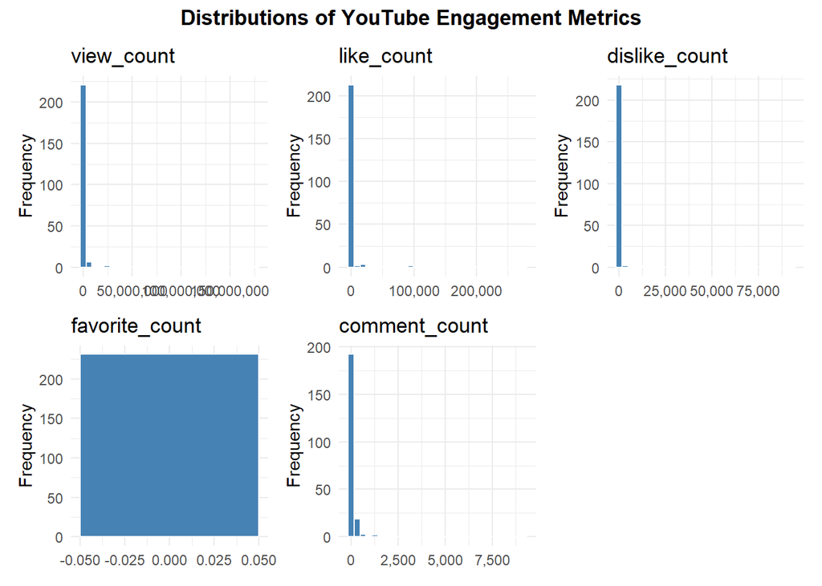

```r
#we first draw the histograms of these variables to examine their distributions.
library(ggplot2)
library(patchwork)

# Variables to check
vars <- c("view_count", "like_count", "dislike_count", "favorite_count", "comment_count")

# Create histograms for each variable
plots <- lapply(vars, function(v) {
  ggplot(youtube, aes_string(x = v)) +
    geom_histogram(bins = 30, fill = "steelblue", color = "white") +
    scale_x_continuous(labels = scales::comma) +
    labs(title = v, x = NULL, y = "Frequency") +
    theme_minimal()
})

# Combine plots into a grid
final_plot <- wrap_plots(plots, ncol = 3, nrow = 2) +
  plot_annotation(
    title = "Distributions of YouTube Engagement Metrics",
    theme = theme(plot.title = element_text(hjust = 0.5, face = "bold"))
  )

final_plot
```

**we then change the x_limits to get a better plot**

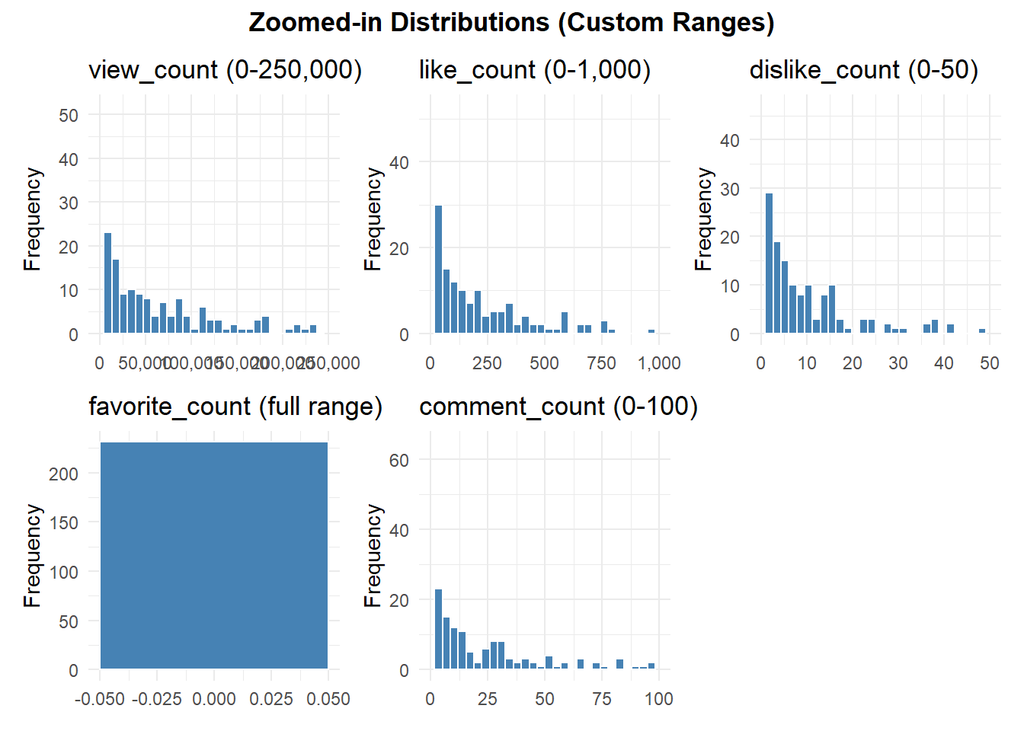

```r
#we then change the x_limits to get a better plot
x_limits <- list(
  c(0, 250000),  # view_count
  c(0, 1000),      # like_count
  c(0, 50),        # dislike_count
  NULL,             # favorite_count
  c(0, 100)         # comment_count
)

plots_zoom <- lapply(seq_along(vars), function(i) {
  v <- vars[i]
  lims <- x_limits[[i]]

  p <- ggplot(youtube, aes_string(x = v)) +
    geom_histogram(bins = 30, fill = "steelblue", color = "white")

  if (!is.null(lims)) {
    p <- p + scale_x_continuous(limits = lims, labels = scales::comma)
    title_range <- paste0(" (", format(lims[1], big.mark = ","), "-", format(lims[2], big.mark = ","), ")")
  } else {
    title_range <- " (full range)"
  }

  p +
    labs(title = paste0(v, title_range),
         x = NULL, y = "Frequency") +
    theme_minimal()
})

#
final_zoom_plot <- wrap_plots(plots_zoom, ncol = 3, nrow = 2) +
  plot_annotation(
    title = "Zoomed-in Distributions (Custom Ranges)",
    theme = theme(plot.title = element_text(hjust = 0.5, face = "bold"))
  )

final_zoom_plot
```

```r
library(dplyr)
# Based on the histograms (full range and zoomed-in):
# 1. View counts: Highly right-skewed, large range -> (ii) Needs transformation
# 2. Like counts: Highly right-skewed, large range -> (ii) Needs transformation
# 3. Dislike counts: Right-skewed, many zeros -> (ii) Needs transformation
# 4. Favorite counts: Constant (all zero) -> (iii) Not appropriate
# 5. Comment counts: Right-skewed, many zeros -> (ii) Needs transformation

# ---- Apply transformations going forward ----
youtube_deid <- youtube_deid %>%
  mutate(
    # log1p(x) = log(1 + x) handles zeros safely
    log_views    = log1p(view_count),     # (ii) Transform
    log_likes    = log1p(like_count),     # (ii) Transform
    log_dislikes = log1p(dislike_count),  # (ii) Transform
    log_comments = log1p(comment_count)   # (ii) Transform
    # favorite_count is excluded from modeling as outcome (iii)
  )

# ---- Final classification table ----
classification <- data.frame(
  Variable = c("View counts", "Like counts", "Dislike counts", "Favorite counts", "Comment counts"),
  Category = c(
    "ii) Needs transformation",
    "ii) Needs transformation",
    "ii) Needs transformation",
    "iii) Not appropriate",
    "ii) Needs transformation"
  ),
  Transformation = c(
    "log1p(view_count)",
    "log1p(like_count)",
    "log1p(dislike_count)",
    "N/A (constant)",
    "log1p(comment_count)"
  )
)

print(classification)
```

```
         Variable                 Category       Transformation
1     View counts ii) Needs transformation    log1p(view_count)
2     Like counts ii) Needs transformation    log1p(like_count)
3  Dislike counts ii) Needs transformation log1p(dislike_count)
4 Favorite counts     iii) Not appropriate       N/A (constant)
5  Comment counts ii) Needs transformation log1p(comment_count)
```

## c.

For each variable in part b. that are appropriate, fit a linear regression model predicting them based upon each of the seven binary flags for characteristics of the ads, such as whether it is funny. Control for year as a continuous covariate.

Discuss the results. Identify the direction of any statistically significant results.

```r
# Define the predictor variables
predictors <- c("funny", "show_product_quickly", "patriotic",
                "celebrity", "danger", "animals", "use_sex", "year")

# define the outcome variables
outcomes <- c("log_views", "log_likes", "log_dislikes", "log_comments")

# Fit model
models <- lapply(outcomes, function(outcome) {
  formula <- as.formula(
    paste(outcome, "~", paste(predictors, collapse = " + "))
  )
  lm(formula, data = youtube_deid)
})

# Name the list for clarity
names(models) <- outcomes

lapply(models, summary)
```

```
$log_views

Call:
lm(formula = formula, data = youtube_deid)

Residuals:
    Min      1Q  Median      3Q     Max
-7.7742 -1.6152  0.1311  1.7036  8.4481

Coefficients:
                          Estimate Std. Error t value Pr(>|t|)
(Intercept)              -31.55016   71.00538  -0.444    0.657
funnyTRUE                  0.56492    0.46702   1.210    0.228
show_product_quicklyTRUE   0.21089    0.40530   0.520    0.603
patrioticTRUE              0.50699    0.53811   0.942    0.347
celebrityTRUE              0.03548    0.42228   0.084    0.933
dangerTRUE                 0.63131    0.41812   1.510    0.132
animalsTRUE               -0.31002    0.39348  -0.788    0.432
use_sexTRUE               -0.38671    0.44782  -0.864    0.389
year                       0.02053    0.03531   0.582    0.561

Residual standard error: 2.787 on 222 degrees of freedom
  (16 observations deleted due to missingness)
Multiple R-squared:  0.02694,   Adjusted R-squared:  -0.008122
F-statistic: 0.7684 on 8 and 222 DF,  p-value: 0.631


$log_likes

Call:
lm(formula = formula, data = youtube_deid)

Residuals:
    Min      1Q  Median      3Q     Max
-5.2860 -1.6333  0.0868  1.4911  7.7431

Coefficients:
                           Estimate Std. Error t value Pr(>|t|)
(Intercept)              -150.51357   63.45723  -2.372   0.0186 *
funnyTRUE                   0.47476    0.41816   1.135   0.2575
```

[output cut: 57 more lines]

```
funnyTRUE                  0.21954    0.34528   0.636   0.5256
show_product_quicklyTRUE   0.40939    0.30229   1.354   0.1771
patrioticTRUE              0.66698    0.39902   1.672   0.0961 .
celebrityTRUE              0.29767    0.31541   0.944   0.3464
dangerTRUE                 0.17784    0.31069   0.572   0.5677
animalsTRUE               -0.26802    0.29347  -0.913   0.3621
use_sexTRUE               -0.39323    0.33163  -1.186   0.2370
year                       0.05034    0.02632   1.913   0.0571 .
---
Signif. codes:  0 '***' 0.001 '**' 0.01 '*' 0.05 '.' 0.1 ' ' 1

Residual standard error: 2.039 on 213 degrees of freedom
  (25 observations deleted due to missingness)
Multiple R-squared:  0.06535,   Adjusted R-squared:  0.03025
F-statistic: 1.862 on 8 and 213 DF,  p-value: 0.06748
```

**Discussion of Results (based on model summaries above):**

```r
# Discussion of Results (based on model summaries above):

# 1. log_views:
#    - No predictors statistically significant at p < 0.05.
#    - Conclusion: Neither year nor ad characteristics explain
#      variation in view counts after transformation.
#
# 2. log_likes:
#    - year: Positive, significant (Estimate ≈ 0.07685, p ≈ 0.0157)
#    - Conclusion: Likes have increased in more recent years,
#      controlling for ad features.
#
# 3. log_dislikes:
#    - year: Positive, significant (Estimate ≈ 0.09207, p ≈ 0.000626)
#    - patriotic: Positive, marginal (p ≈ 0.0531)
#    - Conclusion: Dislikes have increased over time; patriotic ads
#      may receive slightly more dislikes (weak evidence).
#
# 4. log_comments:
#    - No predictors significant at p < 0.05.
#    - year: Positive, marginal (p ≈ 0.0571)
#    - Conclusion: Weak evidence that comments have increased over time.
#
# Overall:
#    - Year is the most consistent predictor, positively associated
#      with likes, dislikes, and marginally comments.
#    - No ad characteristic shows strong, consistent significance.
```

## d.

Consider only the outcome of view counts. Calculate \(\hat{\beta}\) manually (without using `lm`) by first creating a proper design matrix, then using matrix algebra to estimate \(\beta\). Confirm that you get the same result as `lm` did in part c.

```
In this problem, I applied the QR decomposition method learned in STATS 600, Lab 2.

This approach offers two significant advantages over the standard normal equation method, which relies on calculating $(X^T X)^{-1}$:

Improved Computational Efficiency: The complexity is reduced from $O(p^3)$ to $O(np^2)$, making it much faster for datasets with many predictors.

Enhanced Numerical Stability: It avoids the explicit calculation of $(X^T X)^{-1}$, which can be inaccurate or fail completely if the matrix is ill-conditioned (i.e., has high multicollinearity).
```

[figure not shown]

```r
# define variables
response_var <- "log_views"
predictor_vars <- c("funny", "show_product_quickly", "patriotic",
                    "celebrity", "danger", "animals", "use_sex", "year")
all_model_vars <- c(response_var, predictor_vars)

# using na.omit to remove rows with any NA in the relevant columns
youtube_clean <- na.omit(youtube_deid[, all_model_vars])

y <- youtube_clean$log_views
X <- as.matrix(cbind(intercept = 1, youtube_clean[, predictor_vars]))


# using QR decomposition to solve for beta_hat
qr_decomposition <- qr(X)

Q <- qr.Q(qr_decomposition)
R <- qr.R(qr_decomposition)


# Calculate beta_hat using the QR components
beta_hat_qr <- solve(R) %*% t(Q) %*% y

# Compare with lm results
results <- cbind(
  Manual_QR = beta_hat_qr,
  LM_Function = coef(models$log_views)
)

print(results)
```

```
                                   LM_Function
intercept            -31.55015804 -31.55015804
funny                  0.56492445   0.56492445
show_product_quickly   0.21088918   0.21088918
patriotic              0.50699051   0.50699051
celebrity              0.03547862   0.03547862
danger                 0.63131085   0.63131085
animals               -0.31001838  -0.31001838
use_sex               -0.38670726  -0.38670726
year                   0.02053399   0.02053399
```